# Flight Activity

## by Chris Sharkey

## Investigation Overview

2020 has been, in a word, "unprecedented". One of the industries hit the hardest by the COVID-19 pandemic is the airline industry. I was curious about the similarities and differences between the current crisis and the September 11th World Trade Center attacks in 2001.

## Dataset Overview

I pulled two months of flight activity data from the [US Bureau of Transportation Statistics](https://www.transtats.bts.gov/DL_SelectFields.asp). The first month is from September 2001 and the second month is from March of 2020.

## Flights Vs Cancellations in September 2001

We are going to start by exploring the September 2001 data. Let's start by looking at the number of flights vs the number of cancellations during the month. Notice how there is a huge spike in cancellations with all flights being cancelled on September 12th.

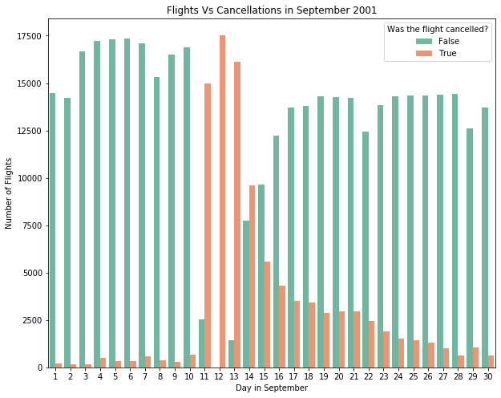

```python
plt.figure(figsize=[10,8])
sb.countplot(data=flights_01, x='DAY_OF_MONTH', hue='CANCELLED', palette='Set2');
plt.title('Flights Vs Cancellations in September 2001')
plt.xlabel('Day in September')
plt.ylabel('Number of Flights')
plt.legend(title='Was the flight cancelled?');
```

## Distribution of Departure Delays During the Week of September 9th

Now that we've seen the trends over the course of the month, let's focus on the week of September 9th. During this week, there was great volatility in the overall trend of departure delays. Notice how on the 9th and the 10th, there is a very tight distribution of departure delays around 0. Any negative departure delays mean that the flight left the gate early. Even though there is usually some skew to having longer delays due to a few outliers, on September 13th, 14, and 15th, there was far greater skew. There were no flights on September 12th.

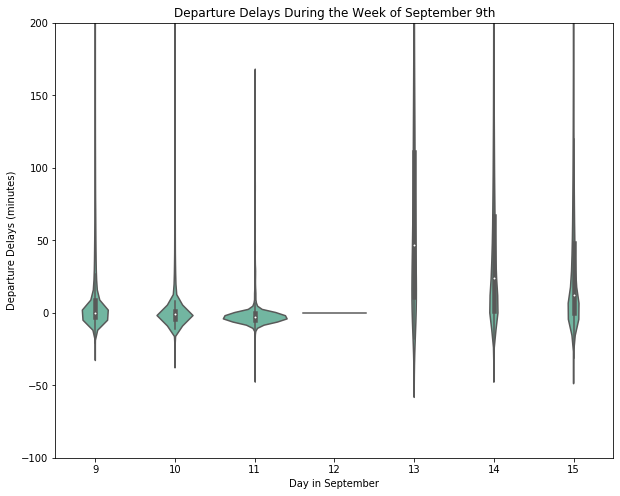

```python
base_color = sb.color_palette('Set2')[0]
plt.figure(figsize=[10,8])
plt.ylim(-100,200)
sb.violinplot(data=flights_sep_week, x='DAY_OF_MONTH', y='DEP_DELAY', color=base_color)
plt.title('Departure Delays During the Week of September 9th')
plt.xlabel('Day in September')
plt.ylabel('Departure Delays (minutes)');
```

## Departure Delays by Airline

So what was the impact of the departure delays on the top four airlines: Southwest Airlines, Delta Airlines, American Airlines, and United Airlines? While all airlines were impacted by the delays, Southwest and United faired better than Delta and American.

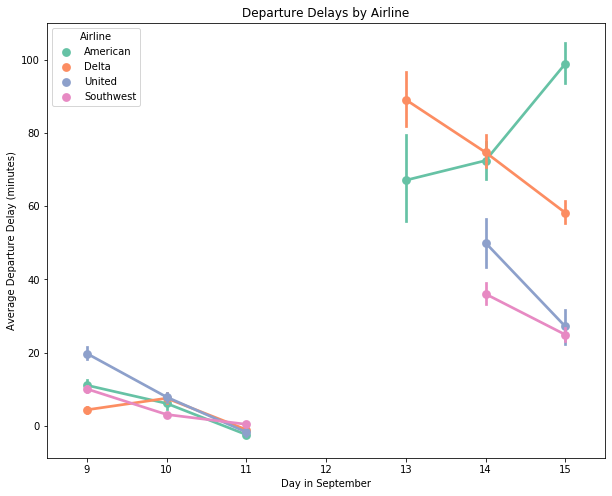

```python
plt.figure(figsize=[10,8])
sb.pointplot(data=carriers_sep_week, x='DAY_OF_MONTH', y='DEP_DELAY', hue='OP_UNIQUE_CARRIER', palette='Set2')
plt.title('Departure Delays by Airline')
plt.xlabel('Day in September')
plt.ylabel('Average Departure Delay (minutes)')
plt.legend(title='Airline', loc='upper left');
```

## Departure Delays by Airport

So what was the impact of the departure delays on three of the United States' largest airports: Chicago O'Hare, Atlanta, and Dallas-Fort Worth? While all airports were impacted by the delays, Chicago O'Hare had many delays on Thursday but improved on Friday and Saturday.

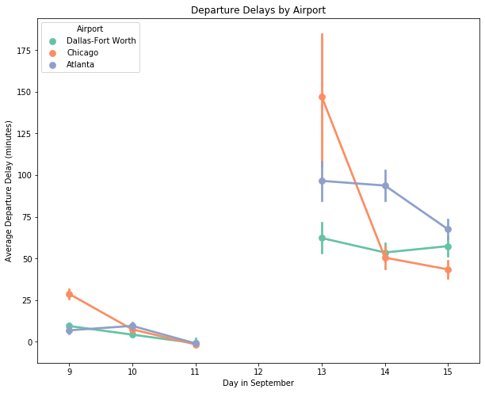

```python
plt.figure(figsize=[10,8])
sb.pointplot(data=origins_sep_week, x='DAY_OF_MONTH', y='DEP_DELAY', hue='ORIGIN', palette='Set2')
plt.title('Departure Delays by Airport')
plt.xlabel('Day in September')
plt.ylabel('Average Departure Delay (minutes)')
plt.legend(title='Airport', loc='upper left');
```

## Flights Vs Cancellations in March 2020

Now that we've looked at analysis for September 11th, let's move on to March 2020 and the impact of the COVID-19 pandemic on United States flight patterns. Notice that the cancellation of flights slowly grew, starting at the middle of the month.

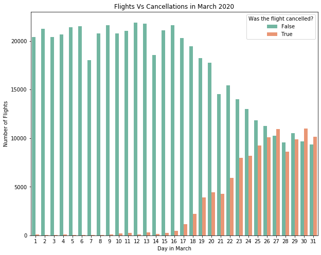

```python
plt.figure(figsize=[10,8]) #Make the figure larger
sb.countplot(data=flights_20, x='DAY_OF_MONTH', hue='CANCELLED', palette='Set2');
plt.title('Flights Vs Cancellations in March 2020')
plt.xlabel('Day in March')
plt.ylabel('Number of Flights')
plt.legend(title='Was the flight cancelled?');
```

## Average Flight Time in March 2020

Number of flights and cancellations is one way to measure airline industry health. While not as stark, we can also see a decrease in the average flight time during the latter half of the month.

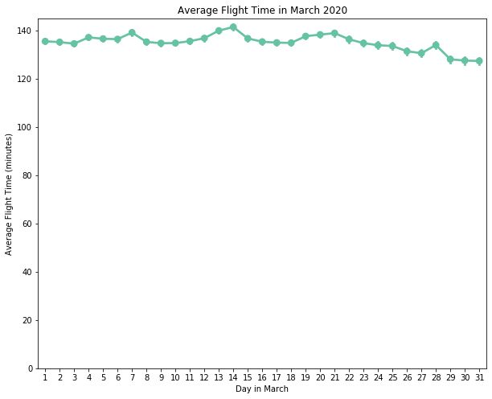

```python
plt.figure(figsize=[10,8])
plt.ylim(0,145)
sb.pointplot(data=flights_20, x='DAY_OF_MONTH', y='ACTUAL_ELAPSED_TIME', color=base_color)
plt.title('Average Flight Time in March 2020')
plt.xlabel('Day in March')
plt.ylabel('Average Flight Time (minutes)');
```

## Average Flight Time by Airline

When we split out the average flight time by carrier, the decline in average flight time seems to be dispersed and is not quite noticeable.

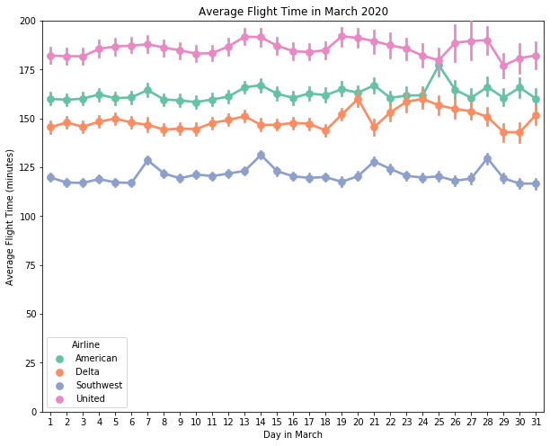

```python
plt.figure(figsize=[10,8])
plt.ylim(0,200)
sb.pointplot(data=carriers_march, x='DAY_OF_MONTH', y='ACTUAL_ELAPSED_TIME', hue='OP_UNIQUE_CARRIER', palette='Set2')
plt.title('Average Flight Time in March 2020')
plt.xlabel('Day in March')
plt.ylabel('Average Flight Time (minutes)')
plt.legend(title='Airline', loc='lower left');
```

## Average Flight Time by Airport

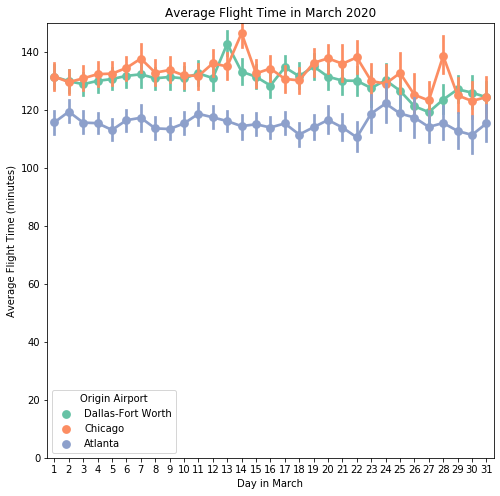

```python
plt.figure(figsize=[8,8])
plt.ylim(0,150)
sb.pointplot(data=origins_march, x='DAY_OF_MONTH', y='ACTUAL_ELAPSED_TIME', hue='ORIGIN', palette='Set2')
plt.title('Average Flight Time in March 2020')
plt.xlabel('Day in March')
plt.ylabel('Average Flight Time (minutes)')
plt.legend(title='Origin Airport', loc='lower left');
```

## Conclusion

In conclusion, the crises of September 11, 2001 and the COVID-19 pandemic are two very different crises with different time horizons and different effects on the airline industry. While the September 11th crisis had a sudden and sharp impact on flight activity, the number of flights rebounded quickly. The COVID-19 pandemic, however, has long-lasting consequences for the airline industry. Even now, in October 2020, flight activities are still lower than the were a year ago. Even a predictive analysis (while interesting) could not tell us exactly how long this could last.